# Project:Brazil Medical Appointment No Show

#### Neighbourhood

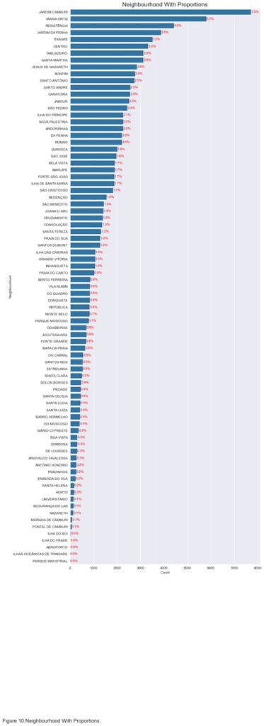

```python
#plotting an horizontal bar chart with proportions

rcParams["figure.figsize"]=10,30

proportion_countplot("Neighbourhood",df_appointment)

plt.xlabel("Count")
plt.ylabel("Neighbourhood")
plt.title("Neighbourhood With Proportions",fontsize="xx-large")
txt="Figure 10.Neighbourhood With Proportions."
plt.figtext(0.05,-0.09, txt, wrap= True, horizontalalignment="center", fontsize= 15);
```

Jardim Camburi neighbourhood represent 7.0% of the patients which is the highest of all neighbourhood. We'll create a pivot table for neighborhood from patients who did not show up dataframe and plot a graph for it.

```python
# creating a pivot table for neighbourhood and duration group using count of no show for patients who did not show up
neighbor_df=pd.DataFrame(pd.pivot_table(no_show,
                                           index="Neighbourhood",
                                           columns=["duration_group"],values="No_show",
                                           aggfunc="count"))


neighbor_df.head(3)
```

| duration_group Neighbourhood | In 24hours | In a Week | In a Month | More than a Month | More than Two Months |
| --- | --- | --- | --- | --- | --- |
| AEROPORTO | 0 | 0 | 1 | 0 | 0 |
| ANDORINHAS | 54 | 164 | 258 | 43 | 2 |
| ANTÔNIO HONÓRIO | 7 | 8 | 30 | 5 | 0 |

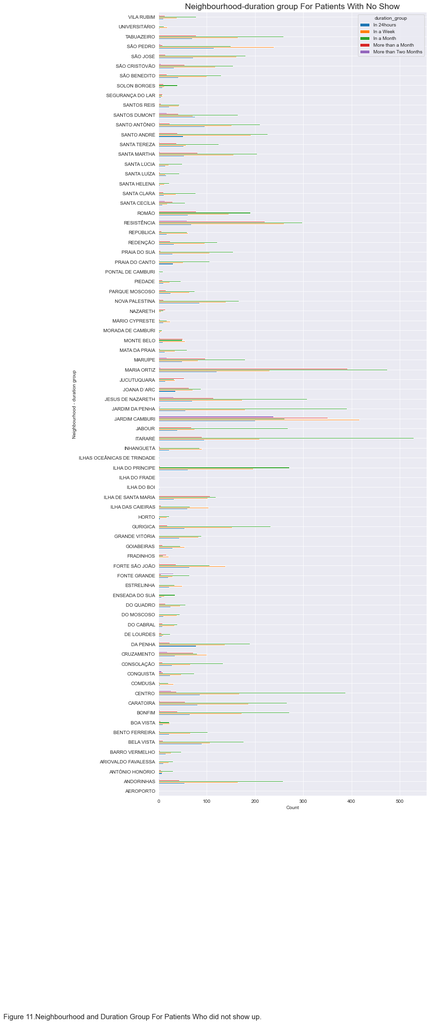

```python
# plotting an horizontal bar chart
neighbor_df.plot(kind="barh")

plt.xlabel("Count")
plt.ylabel("Neighbourhood - duration group")
plt.title("Neighbourhood-duration group For Patients With No Show",fontsize="xx-large")
txt="Figure 11.Neighbourhood and Duration Group For Patients Who did not show up."
plt.figtext(0.05,-0.09, txt, wrap= True, horizontalalignment="center", fontsize= 15);
```

There appears to be a relationship between Neighbourhood, duration group and No show count

#### Message Received

```python
df_appointment["SMS_received"].value_counts()
```

```
0    75039
1    35482
Name: SMS_received, dtype: int64
```

```python
no_show["SMS_received"].value_counts()
```

```
0    12530
1     9784
Name: SMS_received, dtype: int64
```

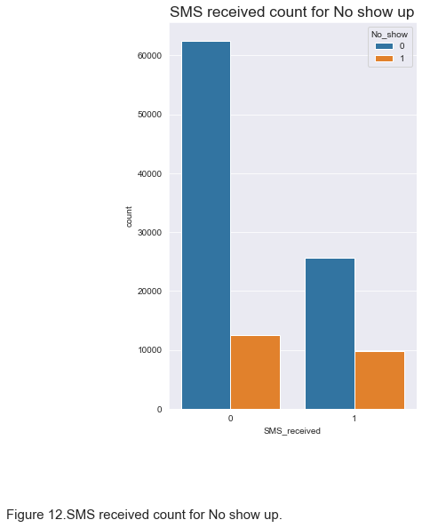

```python
# plotting a countplot for SMS_received
rcParams["figure.figsize"]=5,8
sns.countplot(x="SMS_received",hue="No_show",data=df_appointment)
plt.title("SMS received count for No show up",fontsize="xx-large")

txt="Figure 12.SMS received count for No show up."
plt.figtext(0.05,-0.09, txt, wrap= True, horizontalalignment="center", fontsize= 15)
```

Let's create a pivot table for SMS_received with duration group for patients who did not show up

```python
sms_pivot=pd.pivot_table(no_show, index= "SMS_received",columns="duration_group",values="No_show",
                              aggfunc="count")
sms_pivot
```

| duration_group SMS_received | In 24hours | In a Week | In a Month | More than a Month | More than Two Months |
| --- | --- | --- | --- | --- | --- |
| 0 | 2905 | 3915 | 4343 | 1140 | 227 |
| 1 | 0 | 2744 | 5202 | 1540 | 298 |

## Conclusion

This investigation carried out is exploratory to provide insights for further analysis.

#### Limitations

- No statistical test was done to back up this findings.
- Multicollinearity was not considered in this investigation

REFERENCES

- Kaggle.Medical Appointment No Shows.[https://www.kaggle.com/joniarroba/noshowappointment]
- Wikipedia Bolsa Family Scholarship [https://en.wikipedia.org/wiki/Bolsa_Fam%C3%ADlia]
- Exploring data with Pandas [https;//www.oreilly.com/content/exploring-data-with-pandas/]